# Model Tuner Library Instructions

This notebook provides a guide on how to install and use the `model_tuner` library in a notebook environment like Google Colab.

## Model Tuner Description

The `model_tuner` library is designed to streamline the process of hyperparameter tuning and model optimization for machine learning algorithms. It provides an easy-to-use interface for defining, tuning, and evaluating models.

### Documentation

For detailed documentation and advanced usage of the model_tuner library, please refer to the [model_tuner documentation](https://github.com/uclamii/model_tuner/blob/main/README_long.md).

By following these steps, you should be able to install and use the `model_tuner` library effectively in your notebook environment. If you encounter any issues or have further questions, feel free to reach out for support.

## Installation

To install the `model_tuner` library, use the following command:

```python
! pip install model_tuner
! pip install sns
```

## Importing the Library

After installation, you can import the necessary components from the model_tuner library as shown below:

```python
from model_tuner import Model
import seaborn as sns
from sklearn.ensemble import RandomForestClassifier
```

## Binary Classification with the titanic dataset and Pipeline

```python
titanic = sns.load_dataset('titanic')
titanic.head()
```

|  | survived | pclass | sex | age | sibsp | parch | fare | embarked | class | who | adult_male | deck | embark_town | alive | alone |
| --- | --- | --- | --- | --- | --- | --- | --- | --- | --- | --- | --- | --- | --- | --- | --- |
| 0 | 0 | 3 | male | 22.0 | 1 | 0 | 7.2500 | S | Third | man | True | NaN | Southampton | no | False |
| 1 | 1 | 1 | female | 38.0 | 1 | 0 | 71.2833 | C | First | woman | False | C | Cherbourg | yes | False |
| 2 | 1 | 3 | female | 26.0 | 0 | 0 | 7.9250 | S | Third | woman | False | NaN | Southampton | yes | True |
| 3 | 1 | 1 | female | 35.0 | 1 | 0 | 53.1000 | S | First | woman | False | C | Southampton | yes | False |
| 4 | 0 | 3 | male | 35.0 | 0 | 0 | 8.0500 | S | Third | man | True | NaN | Southampton | no | True |

```python
X = titanic[[col for col in titanic.columns if col != "survived"]]
### Removing repeated data
X = X.drop(columns=['alive', 'class', 'embarked'])
y = titanic['survived']
```

# Defining pipeline steps

Here we look at the columns of the data and work out what data points need what sort of preprocessing, for example we may want to scale the continuous input data. The ordinal data will need converting to appropriate numbers e.g. A-> 0 B-> 1, C-> 3. Or the otherway around. The other categorical data needs one hot encoding.

This can be done easily through the pipeline so that we can ensure there is no data leakage.

This also allows us to handle missing data when it comes to predicting. Using the `OneHotEncoder` with `handle_unknown` set to ignore will generate a new empty column if we have missing data.

```python
X.head()
```

|  | pclass | sex | age | sibsp | parch | fare | who | adult_male | deck | embark_town | alone |
| --- | --- | --- | --- | --- | --- | --- | --- | --- | --- | --- | --- |
| 0 | 3 | male | 22.0 | 1 | 0 | 7.2500 | man | True | NaN | Southampton | False |
| 1 | 1 | female | 38.0 | 1 | 0 | 71.2833 | woman | False | C | Cherbourg | False |
| 2 | 3 | female | 26.0 | 0 | 0 | 7.9250 | woman | False | NaN | Southampton | True |
| 3 | 1 | female | 35.0 | 1 | 0 | 53.1000 | woman | False | C | Southampton | False |
| 4 | 3 | male | 35.0 | 0 | 0 | 8.0500 | man | True | NaN | Southampton | True |

```python
### Defining columns to be scaled and columns to be onehotencoded
from sklearn.preprocessing import OneHotEncoder, OrdinalEncoder
from sklearn.compose import ColumnTransformer
from sklearn.preprocessing import MinMaxScaler
from sklearn.impute import SimpleImputer
from pprint import pprint

ohencoder = OneHotEncoder(handle_unknown="ignore")

ohcols = [
    "embark_town",
    "who",
    "sex",
    "adult_male"
]

ordencoder = OrdinalEncoder()

ordcols = [
    "deck"
]

minmaxscaler = MinMaxScaler()

scalercols = [
    "parch",
    "fare",
    "age",
    "pclass"
]


ct = ColumnTransformer(
    [
        ("OneHotEncoder", ohencoder, ohcols),
        ("OrdinalEncoder", ordencoder, ordcols),
        ("MinMaxScaler", minmaxscaler, scalercols)
    ],
    remainder='passthrough'
)
```

# Defining the model parameters

```python
# random forest definition
rf_name = "rf"
rf = RandomForestClassifier(class_weight="balanced")
tuned_parameters_rf = {
    f"{rf_name}__max_depth": [3, 5, 10],
    f"{rf_name}__n_estimators": [10, 100, 200],
    f"{rf_name}__max_features": [1, 3, 5, 7],
    f"{rf_name}__min_samples_leaf": [1, 2, 3],
}
rf_definition = {
    "clc": rf,
    "estimator_name": rf_name,
    "tuned_parameters": tuned_parameters_rf,
    "randomized_grid": True,
    "n_iter": 20,
    "early": False,
}
```

```python
kfold = False

# Initialize titanic_model
titanic_model_rf = Model(
    name="RandomForest_Titanic",
    estimator_name=rf_definition['estimator_name'],
    calibrate=True,
    estimator=rf_definition['clc'],
    kfold=kfold,
    pipeline_steps=[("Preprocessor", ct),
                    ("Imputer", SimpleImputer())],
    stratify_y=True,
    grid=rf_definition['tuned_parameters'],
    randomized_grid=rf_definition['randomized_grid'],
    n_iter=rf_definition['n_iter'],
    scoring=["roc_auc"],
    random_state=42,
    n_jobs=-1,
)
```

```python
titanic_model_rf.grid_search_param_tuning(X, y, f1_beta_tune=True)
```

```
Pipeline Steps:
========================
┌──────────────────────────────────────────────────────┐
│ Step 1: preprocess_column_transformer_Preprocessor   │
│ ColumnTransformer                                    │
└──────────────────────────────────────────────────────┘
                           │
                           ▼
┌──────────────────────────────────────────────────────┐
│ Step 2: preprocess_imputer_Imputer                   │
│ SimpleImputer                                        │
└──────────────────────────────────────────────────────┘
                           │
                           ▼
┌──────────────────────────────────────────────────────┐
│ Step 3: rf                                           │
│ RandomForestClassifier                               │
└──────────────────────────────────────────────────────┘
```

```
Fitting model with best params and tuning for best threshold ...
```

```
Best score/param set found on validation set:
{'params': {'rf__max_depth': 5,
            'rf__max_features': 5,
            'rf__min_samples_leaf': 3,
            'rf__n_estimators': 200},
 'score': 0.8823529411764707}
Best roc_auc: 0.882
```

```python
X_train, y_train = titanic_model_rf.get_train_data(X, y)
X_valid, y_valid = titanic_model_rf.get_valid_data(X, y)
X_test, y_test = titanic_model_rf.get_test_data(X, y)

titanic_model_rf.fit(X_train, y_train)
```

```python
prob_uncalibrated = titanic_model_rf.predict_proba(X_test)[:, 1]

if titanic_model_rf.calibrate == True:
  titanic_model_rf.calibrateModel(X, y)
```

```
Confusion matrix on validation set:
--------------------------------------------------------------------------------
          Predicted:
            Pos  Neg
--------------------------------------------------------------------------------
Actual: Pos 51 (tp)  17 (fn)
        Neg 12 (fp)  98 (tn)
--------------------------------------------------------------------------------

              precision    recall  f1-score   support

           0       0.85      0.89      0.87       110
           1       0.81      0.75      0.78        68

    accuracy                           0.84       178
   macro avg       0.83      0.82      0.82       178
weighted avg       0.84      0.84      0.84       178

--------------------------------------------------------------------------------
```

```python
metrics = titanic_model_rf.return_metrics(X_test, y_test)
```

```
Confusion matrix on set provided:
--------------------------------------------------------------------------------
          Predicted:
             Pos   Neg
--------------------------------------------------------------------------------
Actual: Pos  51 (tp)   18 (fn)
        Neg   9 (fp)  101 (tn)
--------------------------------------------------------------------------------
--------------------------------------------------------------------------------
{'AUC ROC': 0.8610013175230566,
 'Average Precision': 0.8539173858931898,
 'Brier Score': 0.12738644655373982,
 'Precision/PPV': 0.6790123456790124,
 'Sensitivity': 0.7971014492753623,
 'Specificity': 0.7636363636363637}
--------------------------------------------------------------------------------

              precision    recall  f1-score   support

           0       0.85      0.92      0.88       110
           1       0.85      0.74      0.79        69

    accuracy                           0.85       179
   macro avg       0.85      0.83      0.84       179
weighted avg       0.85      0.85      0.85       179

--------------------------------------------------------------------------------
```

```python
titanic_model_rf.threshold
```

```
{'roc_auc': 0.3}
```

## Calibrating Model

```python
from matplotlib import pyplot as plt
from sklearn.calibration import calibration_curve
```

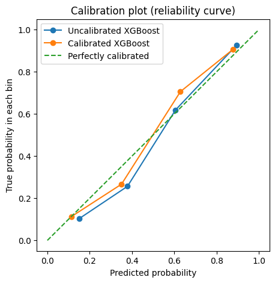

```python
# Get the predicted probabilities for the validation data from the calibrated model
y_prob_calibrated = titanic_model_rf.predict_proba(X_test)[:, 1]

# Compute the calibration curve for the calibrated model
prob_true_calibrated, prob_pred_calibrated = calibration_curve(y_test, y_prob_calibrated, n_bins=4)
prob_true_uncalibrated, prob_pred_uncalibrated = calibration_curve(y_test, prob_uncalibrated, n_bins=4)

# Plot the calibration curves
plt.figure(figsize=(5, 5))
plt.plot(prob_pred_uncalibrated, prob_true_uncalibrated, marker='o', label='Uncalibrated XGBoost')
plt.plot(prob_pred_calibrated, prob_true_calibrated, marker='o', label='Calibrated XGBoost')
plt.plot([0, 1], [0, 1], linestyle='--', label='Perfectly calibrated')
plt.xlabel('Predicted probability')
plt.ylabel('True probability in each bin')
plt.title('Calibration plot (reliability curve)')
plt.legend()
plt.show()
```

# KFold?

If we want to use KFold we can simply set the `kfold` parameter to `True` this will automatically split the data accordingly.

```python
kfold = True

# Initialize titanic_model
titanic_model_kf = Model(
    name="RandomForest_Titanic",
    estimator_name=rf_definition['estimator_name'],
    calibrate=True,
    estimator=rf_definition['clc'],
    kfold=kfold,
    pipeline_steps=[("Preprocessor", ct),
                    ("Imputer", SimpleImputer())],
    stratify_y=True,
    grid=rf_definition['tuned_parameters'],
    randomized_grid=rf_definition['randomized_grid'],
    n_iter=rf_definition['n_iter'],
    scoring=["roc_auc"],
    random_state=42,
    n_jobs=-1,
)
```

```python
#### When using KFold X and y are passed as a whole to the fit method as they
#### as they are split within this into the separate folds.
#### The metrics are assessed over each fold and averaged.

titanic_model_kf.grid_search_param_tuning(X, y, f1_beta_tune=True)
```

```
Pipeline Steps:
========================
┌──────────────────────────────────────────────────────┐
│ Step 1: preprocess_column_transformer_Preprocessor   │
│ ColumnTransformer                                    │
└──────────────────────────────────────────────────────┘
                           │
                           ▼
┌──────────────────────────────────────────────────────┐
│ Step 2: preprocess_imputer_Imputer                   │
│ SimpleImputer                                        │
└──────────────────────────────────────────────────────┘
                           │
                           ▼
┌──────────────────────────────────────────────────────┐
│ Step 3: rf                                           │
│ RandomForestClassifier                               │
└──────────────────────────────────────────────────────┘

# Tuning hyper-parameters for roc_auc
Fitting 10 folds for each of 20 candidates, totalling 200 fits

Best score/param set found on development set:
{0.8785825481707835: {'rf__max_depth': 10,
                      'rf__max_features': 7,
                      'rf__min_samples_leaf': 3,
                      'rf__n_estimators': 100}}

Grid scores on development set:
0.873 (+/-0.083) for {'rf__n_estimators': 200, 'rf__min_samples_leaf': 2, 'rf__max_features': 1, 'rf__max_depth': 10}
0.860 (+/-0.082) for {'rf__n_estimators': 100, 'rf__min_samples_leaf': 1, 'rf__max_features': 3, 'rf__max_depth': 3}
0.859 (+/-0.086) for {'rf__n_estimators': 100, 'rf__min_samples_leaf': 2, 'rf__max_features': 1, 'rf__max_depth': 3}
0.875 (+/-0.080) for {'rf__n_estimators': 200, 'rf__min_samples_leaf': 1, 'rf__max_features': 3, 'rf__max_depth': 10}
0.870 (+/-0.089) for {'rf__n_estimators': 200, 'rf__min_samples_leaf': 3, 'rf__max_features': 5, 'rf__max_depth': 5}
0.873 (+/-0.092) for {'rf__n_estimators': 100, 'rf__min_samples_leaf': 2, 'rf__max_features': 7, 'rf__max_depth': 5}
0.864 (+/-0.085) for {'rf__n_estimators': 10, 'rf__min_samples_leaf': 2, 'rf__max_features': 7, 'rf__max_depth': 3}
0.870 (+/-0.078) for {'rf__n_estimators': 10, 'rf__min_samples_leaf': 1, 'rf__max_features': 3, 'rf__max_depth': 5}
0.876 (+/-0.083) for {'rf__n_estimators': 200, 'rf__min_samples_leaf': 2, 'rf__max_features': 5, 'rf__max_depth': 10}
0.862 (+/-0.086) for {'rf__n_estimators': 200, 'rf__min_samples_leaf': 1, 'rf__max_features': 3, 'rf__max_depth': 3}
0.868 (+/-0.090) for {'rf__n_estimators': 10, 'rf__min_samples_leaf': 1, 'rf__max_features': 3, 'rf__max_depth': 10}
0.872 (+/-0.086) for {'rf__n_estimators': 100, 'rf__min_samples_leaf': 3, 'rf__max_features': 1, 'rf__max_depth': 10}
0.850 (+/-0.074) for {'rf__n_estimators': 10, 'rf__min_samples_leaf': 1, 'rf__max_features': 1, 'rf__max_depth': 3}
0.875 (+/-0.085) for {'rf__n_estimators': 200, 'rf__min_samples_leaf': 3, 'rf__max_features': 1, 'rf__max_depth': 10}
0.864 (+/-0.070) for {'rf__n_estimators': 10, 'rf__min_samples_leaf': 1, 'rf__max_features': 5, 'rf__max_depth': 3}
0.873 (+/-0.081) for {'rf__n_estimators': 10, 'rf__min_samples_leaf': 3, 'rf__max_features': 7, 'rf__max_depth': 5}
0.875 (+/-0.087) for {'rf__n_estimators': 200, 'rf__min_samples_leaf': 1, 'rf__max_features': 5, 'rf__max_depth': 5}
0.876 (+/-0.083) for {'rf__n_estimators': 100, 'rf__min_samples_leaf': 2, 'rf__max_features': 1, 'rf__max_depth': 10}
0.879 (+/-0.076) for {'rf__n_estimators': 100, 'rf__min_samples_leaf': 3, 'rf__max_features': 7, 'rf__max_depth': 10}
0.860 (+/-0.095) for {'rf__n_estimators': 10, 'rf__min_samples_leaf': 3, 'rf__max_features': 1, 'rf__max_depth': 5}
Fitting model with best params and tuning for best threshold ...
```

```
Fitting model with best params and tuning for best threshold ...
```

```
Fitting model with best params and tuning for best threshold ...
```

```
Fitting model with best params and tuning for best threshold ...
```

```
Fitting model with best params and tuning for best threshold ...
```

```
Fitting model with best params and tuning for best threshold ...
```

```
Fitting model with best params and tuning for best threshold ...
```

```
Fitting model with best params and tuning for best threshold ...
```

```
Fitting model with best params and tuning for best threshold ...
```

```
Fitting model with best params and tuning for best threshold ...
```

```python
#### When using KFold X and y are passed as a whole to the fit method as they
#### as they are split within this into the separate folds.
#### The metrics are assessed over each fold and averaged.

titanic_model_kf.fit(X, y)
```

```python
titanic_model_kf.threshold
```

```
{'roc_auc': 0.331}
```

```python
titanic_model_kf.return_metrics(X, y)
```

```
Detailed classification report for RandomForest_Titanic:

Confusion Matrix Average Across 10 Folds for roc_auc:
--------------------------------------------------------------------------------
          Predicted:
            Pos  Neg
--------------------------------------------------------------------------------
Actual: Pos 25 (tp)   8 (fn)
        Neg  6 (fp)  48 (tn)
--------------------------------------------------------------------------------

Classification Report Averaged Across All Folds for roc_auc:
              precision    recall  f1-score   support

           0       0.85      0.88      0.86       549
           1       0.79      0.75      0.77       342

    accuracy                           0.83       891
   macro avg       0.82      0.81      0.82       891
weighted avg       0.83      0.83      0.83       891

--------------------------------------------------------------------------------
The model is trained on the full development set.
The scores are computed on the full evaluation set.

--------------------------------------------------------------------------------
Average performance across 10 Folds:
{'AUC ROC': 0.8773038791274086,
 'Average Precision': 0.8580546229225494,
 'Brier Score': 0.127519061779156,
 'Precision/PPV': 0.6890863117084275,
 'Sensitivity': 0.8362184873949581,
 'Specificity': 0.7633670033670035}
--------------------------------------------------------------------------------
```